# DataWhale 组队学习 R语言数据分析 Task02 数据清洗与准备

June Yao

2021-07-15

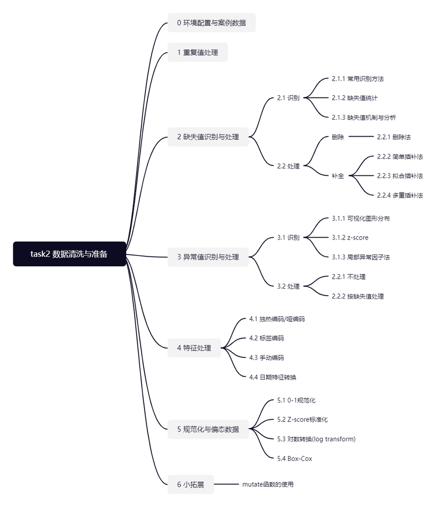

Task02共计6个知识点，预计需学习5~8小时，请安排好学习任务。

## 0 环境配置

```r
library(mlbench)  #将会使用到包中的BostonHousing数据集
library(funModeling)  # 探索性数据分析工具包，本节内容中将会使用到它的status()函数，打印整体数据质量
library(tidyverse)  # 数据转化工具包，本节内容中将会使用它包含的dplyr中的管道函数 %>%
library(VIM)  # 缺失值可视化工具包，本节内容中将会使用到它的aggr()函数
library(mice)  #缺失值处理工具包，本节内容会使用它来进行多重插补
library(Rlof)  #用于LOF异常值检测方法，本节内容将会使用到它的lof()函数
library(fastDummies)  #用于生成dummy的包，本节内容将会使用到它的dummy_cols()函数
library(sjmisc)  #用于生成dummy的包，本节内容将会使用到它的to_dummy()函数
library(MASS)  #基于此包进行box-cox转换
library(dlookr)  #本节内容将会使用到它的transform()函数
```

## 0 案例数据

本节内容将会使用到两个数据集。

### 数据集1 h1n1流感问卷数据集

#### 数据说明

目前提供的数据集来自关于h1n1流感调查问卷的部分内容，可以从这个网站上看到具体字段的详细说明：https://www.drivendata.org/competitions/66/flu-shot-learning/page/211/

数据集包含26,707个受访者数据，共有32个特征+1个标签（是否接种h1n1疫苗）。

#### 加载并查看部分数据

首先加载数据，了解数据集大小。

```r
h1n1_data <- read.csv("./datasets/h1n1_flu.csv", header = TRUE)
dim(h1n1_data)
```

```
## [1] 26707    33
```

注：为了简化本章的示例，我们在这32个特征中，筛选出了10个特征，作为一个子集，来学习如何使用R做数据清洗与准备。如有兴趣，可以把下面这块筛选去掉，自己用完整数据集做一次探索。

```r
h1n1_data <- h1n1_data[, c(1, 3, 11, 12, 15, 16, 19, 20, 22, 23, 33)]
head(h1n1_data)
```

```
##   respondent_id h1n1_knowledge doctor_recc_h1n1 chronic_med_condition
## 1             0              0                0                     0
## 2             1              2                0                     0
## 3             2              1               NA                     1
## 4             3              1                0                     1
## 5             4              1                0                     0
## 6             5              1                0                     0
##   health_insurance opinion_h1n1_vacc_effective     age_group        education
## 1                1                           3 55 - 64 Years       < 12 Years
## 2                1                           5 35 - 44 Years         12 Years
## 3               NA                           3 18 - 34 Years College Graduate
## 4               NA                           3     65+ Years         12 Years
## 5               NA                           3 45 - 54 Years     Some College
## 6               NA                           5     65+ Years         12 Years
##      sex            income_poverty h1n1_vaccine
## 1 Female             Below Poverty            0
## 2   Male             Below Poverty            0
## 3   Male <= $75,000, Above Poverty            0
## 4 Female             Below Poverty            0
## 5 Female <= $75,000, Above Poverty            0
## 6   Male <= $75,000, Above Poverty            0
```